# GRanD dam and river connectivity exploration

Emi, Brian, Korrina

8/20/2021

# Data exploration for GRanD and FFR dam purpose project

## Project overview

Exploratory analyses using the combined GRanD and FFR datasets. Our goal is to examine whether there are patterns among river connectivity measures and dams by their reported main use (e.g., hydroelectricity, irrigation) and by continent. We are interested in examining whether there are differences in river connectivity status by dam use - especially with regard to hydroelectricity.

##Data processing steps We merged the GRanD and FFR datasets using the unique GRAND_ID for a total of n = 7303 dams associated with river attributes in the FFR. We reduced the dataset to a subset of observations (n = 3278) that were used in Grill et al. 2019 as indicated by the field “INC”= 1. Dams are commonly used for multiple purposes that can have competing water management practices. We expect that hydroelectricity will have a dominant effect on river connectivity regardless of whether it is labeled as the primary or secondary main use for a dam. We created a new dam use class variable called “MAIN_HYDRO” which labels dams that have Hydroelectricity listed for any use as “Hydroelectricity”. We also created a new other category (“Other expanded”) that consolidated dams labeled as “Other”, “Fisheries”, and “Recreation”.

Below are summary statistics of river connectivity measures by dam use and exploratory box-plots of the distribution of connectivity measures by dam use and continent.

## Number of dams by dam use and continent

Note there are 714 dams missing a main use.

```
##
##                 Hydroelectricity Flood control Water supply Irrigation
##   Africa                      87             1           62        160
##   Asia                       242            38           12        228
##   Australia                   32             0           35         23
##   Europe                     409            12           85         77
##   North America              309           125          145        113
##   South America               86             4           11         27
##
##                 Navigation Other expanded
##   Africa                 0              3  47
##   Asia                   1              1 445
##   Australia              0              0   7
##   Europe                 3             13  84
##   North America         14            206  15
##   South America          0              0 116
```

## Summary statistics of river connectivity measures

Mean, standard deviation, and range of connectivity values are reported by dam use. Metrics include: CSI = connectivity status index; DOF = degree of fragmentation; DOR = degree of regulation

| Dam use MAIN_HYDRO | CSI mean_csi | CSI sd_csi | CSI min_csi | CSI max_csi | DOF mean_dof | DOF sd_dof | DOF min_dof | DOF max_dof | DOR mean_dor | DOR sd_dor | DOR min_dor | DOR max_dor |
| --- | --- | --- | --- | --- | --- | --- | --- | --- | --- | --- | --- | --- |
| Hydroelectricity | 77.95 | 28.37 | 13.61 | 100 | 36.87 | 45.44 | 0 | 100 | 20.76 | 35.10 | 0 | 100.0 |
| Flood control | 76.59 | 28.38 | 20.16 | 100 | 34.98 | 43.63 | 0 | 100 | 27.17 | 39.06 | 0 | 100.0 |
| Water supply | 74.34 | 29.10 | 19.16 | 100 | 40.30 | 45.25 | 0 | 100 | 26.67 | 38.09 | 0 | 100.0 |
| Irrigation | 69.14 | 30.85 | 6.88 | 100 | 47.46 | 46.51 | 0 | 100 | 32.14 | 40.14 | 0 | 100.0 |
| Navigation | 80.55 | 25.64 | 31.81 | 100 | 33.50 | 46.20 | 0 | 100 | 16.63 | 24.91 | 0 | 80.4 |
| Other expanded | 78.95 | 26.93 | 21.66 | 100 | 34.53 | 43.14 | 0 | 100 | 22.71 | 35.89 | 0 | 100.0 |
|  | 77.73 | 27.05 | 17.12 | 100 | 38.21 | 45.15 | 0 | 100 | 19.36 | 32.76 | 0 | 100.0 |

## Boxplots of river attributes by dam use and continent

Boxplots illustrate the distribution of river attribute values by our dam use classes and across continents. Group differences within a continent are tested using Kruskal-Wallis non-parametric group mean test with p-values reported.

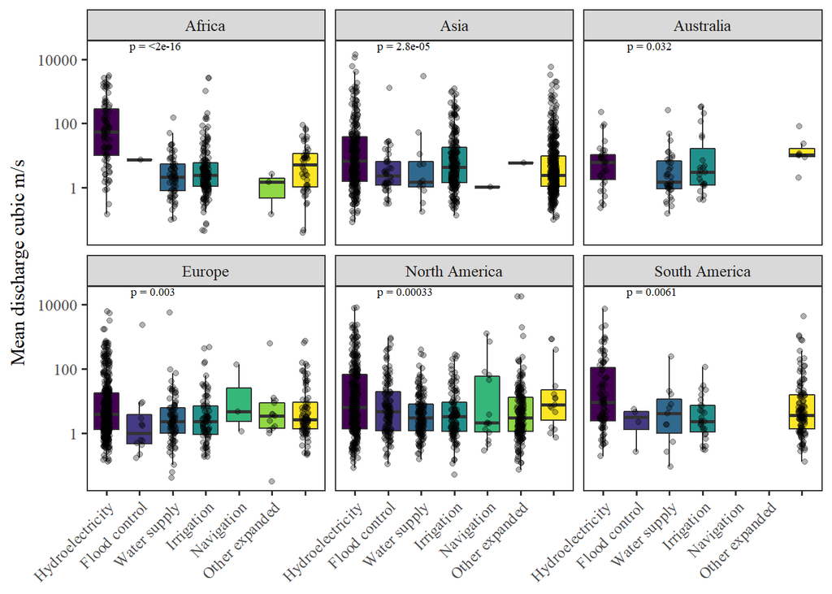

River discharge distributions are different across dam types for all of the continents, as indicated by the Kruskal-Wallis test (p-value <0.05). In general, rivers that have dams used for hydroelectricity, tend to be on larger rivers with greater discharge compared to dams used for other purposes. But there is a great deal of variation within these classes.

## Boxplots river connectivity measures

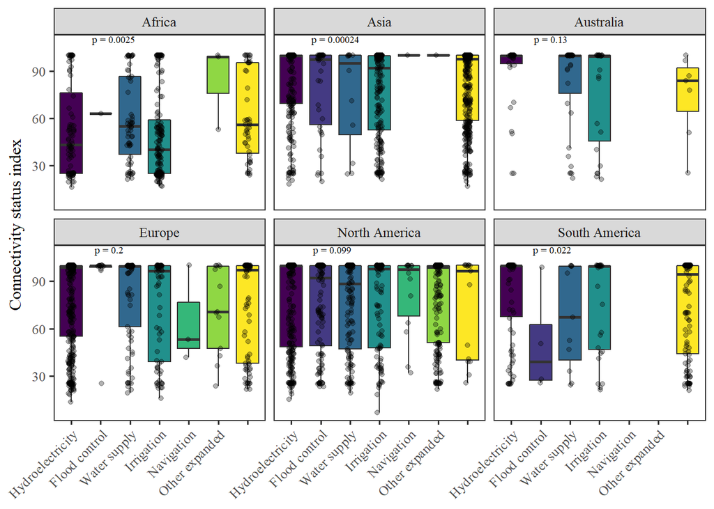

CSI values differed among dam use classes In Africa, Asia, and S America. We did not find significant differences in CSI mean values among dam types in Australia, Europe, and N America (kruskal-wallis p>0.05). In Africa, dams used for hydroelectric and irrigation had lower CSI compared to other dam types.

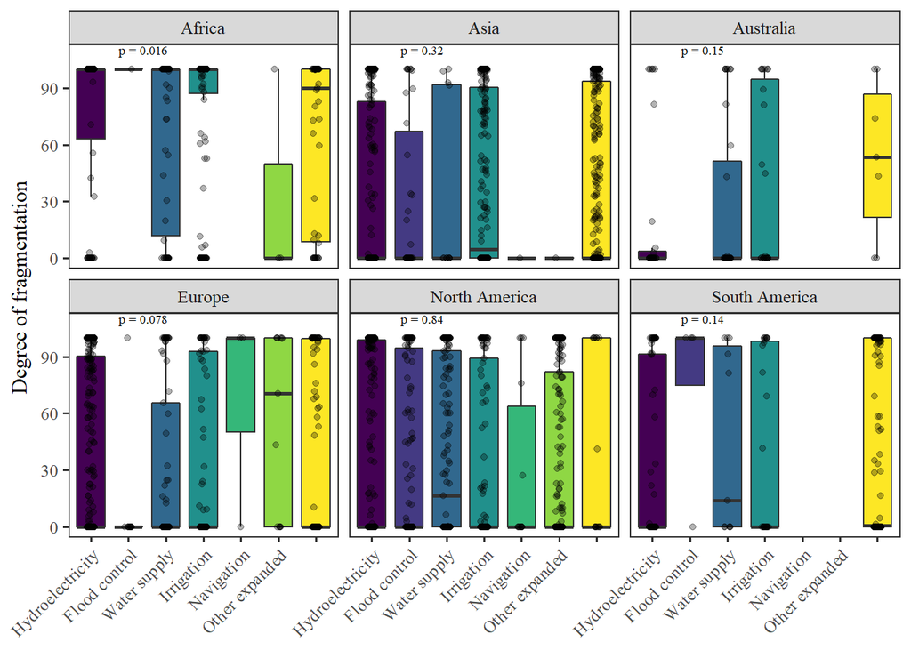

We did not find significant differences in degree of fragmentation values among dam types across most continents except Africa. This may not be surprising because dams regardless of how they are used can fragment river networks. We should read up more on how degree of fragmentation was determined.

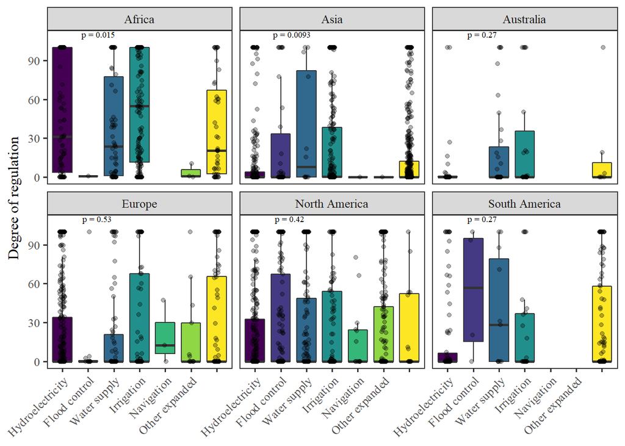

## Boxplots examining hydroelectric dams and all other dam types by river order

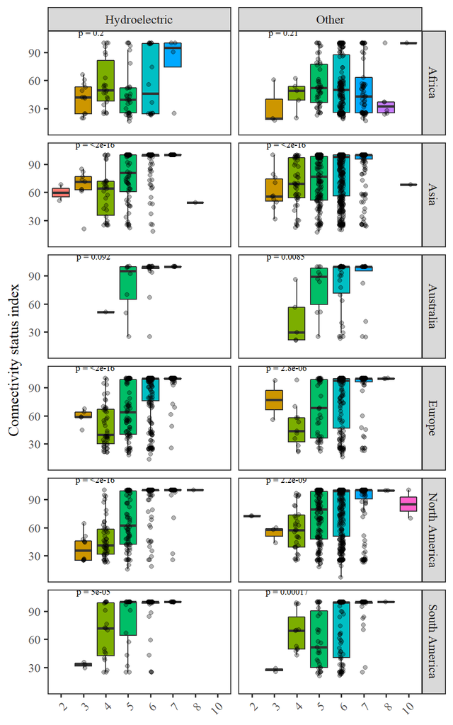

Here I collapsed dam types into Hydroelectric or other and plotted CSI against river order (where lower order numbers indicate larger rivers. We can see that connectivity measures decrease with larger rivers - there may be a threshold between rivers 6 and higher having greater connectivity compared to rivers <6.